# 🏎️ Nina's F1 Predictions: 2026 Monaco Grand Prix (Round 6)

## Circuit de Monaco — June 5-7, 2026

**Model version:** v1.0+Q (retrospective) **Confidence:** HIGH

### What This Is

A machine learning model that predicts Formula 1 race results from 24 features — the same kinds of data a race engineer considers when building race strategy. The model trains on every race through the round before this one (2026 weighted 10x over 2023-2025 history), takes the **actual qualifying grid** and **live qualifying sector times** for this weekend, then runs 10,000 simulated races to estimate podium probabilities.

> **This is a reconstructed prediction.** The model was rebuilt using only data available before the Monaco GP — nothing from the race itself enters the model — so the accuracy check in the final section is a fair test. It backfills the season scoreboard for a race weekend that ran before the model was caught up.

```
============================================================
  🤖 XGBOOST v1.0 — 24 features, trained through Round 5
============================================================
  Training rows: 1,507
  Leave-one-out MAE: 2.27 positions (honest)
  Residual StdDev:   2.76

  Top features:
    grid_position             0.240
    team_pit_strategy         0.086
    driver_avg_finish         0.063
    car_pace                  0.063
    car_speed                 0.053
    sector2_delta             0.051
    is_2026                   0.037
    quali_race_gap            0.037
```

## 1. Qualifying & Blended Car Pace

Grid position is the model's single strongest predictor. This weekend's actual qualifying result sets the starting grid, and the team-level pace is a 30/70 blend of season-to-date form and qualifying performance. Live Monaco sector deltas from qualifying replace the historical track profile.

```
======================================================================
  🏁 QUALIFYING GRID — 2026 Monaco GP
======================================================================

  Pos  Driver                  Team                Blend Pace
  ------------------------------------------------------------
  P 1  Kimi Antonelli          Mercedes            P   3.5
  P 2  Max Verstappen          Red Bull Racing     P   5.6
  P 3  Lewis Hamilton          Ferrari             P   3.7
  P 4  Charles Leclerc         Ferrari             P   3.7
  P 5  Isack Hadjar            Red Bull Racing     P   5.6
  P 6  George Russell          Mercedes            P   3.5
  P 7  Oscar Piastri           McLaren             P   8.4
  P 8  Lando Norris            McLaren             P   8.4
  P 9  Pierre Gasly            Alpine              P  11.2
  P10  Liam Lawson             Racing Bulls        P  12.5
  P11  Alexander Albon         Williams            P  12.3
  P12  Carlos Sainz            Williams            P  12.3
  P13  Nico Hulkenberg         Audi                P  14.4
  P14  Franco Colapinto        Alpine              P  11.2
  P15  Arvid Lindblad          Racing Bulls        P  12.5
  P16  Gabriel Bortoleto       Audi                P  14.4
  P17  Esteban Ocon            Haas F1 Team        P  16.1
  P18  Sergio Perez            Cadillac            P  18.3
  P19  Oliver Bearman          Haas F1 Team        P  16.1
  P20  Valtteri Bottas         Cadillac            P  18.3
  P21  Fernando Alonso         Aston Martin        P  20.3
  P22  Lance Stroll            Aston Martin        P  20.3

  🌡️ Race conditions: 23.7°C, 62% humidity, DRY
```

## 2. Predicted Finish

Each driver's predicted finishing position, with the inputs that drove it: grid (actual qualifying), car (blended team pace), and the position change the model expects relative to the grid.

```
================================================================================
  🏁 PREDICTED FINISH — 2026 Monaco GP
================================================================================

  Pos  Driver                  Team                Grid   Pred  ΔGrid
  ----------------------------------------------------------------------
  P 1  Kimi Antonelli          Mercedes            P 1  P 1.3      =
  P 2  Charles Leclerc         Ferrari             P 4  P 2.6     +2
  P 3  Lewis Hamilton          Ferrari             P 3  P 3.2      =
  P 4  Max Verstappen          Red Bull Racing     P 2  P 3.9     -2
  P 5  George Russell          Mercedes            P 6  P 4.8     +1
  P 6  Isack Hadjar            Red Bull Racing     P 5  P 5.2     -1
  P 7  Lando Norris            McLaren             P 8  P 8.2     +1
  P 8  Oscar Piastri           McLaren             P 7  P 8.7     -1
  P 9  Pierre Gasly            Alpine              P 9  P 9.0      =
  P10  Liam Lawson             Racing Bulls        P10  P 9.9      =
  P11  Arvid Lindblad          Racing Bulls        P15  P10.8     +4
  P12  Carlos Sainz            Williams            P12  P11.5      =
  P13  Alexander Albon         Williams            P11  P12.2     -2
  P14  Franco Colapinto        Alpine              P14  P12.7      =
  P15  Nico Hulkenberg         Audi                P13  P13.0     -2
  P16  Gabriel Bortoleto       Audi                P16  P15.1      =
  P17  Oliver Bearman          Haas F1 Team        P19  P15.4     +2
  P18  Esteban Ocon            Haas F1 Team        P17  P16.5     -1
  P19  Sergio Perez            Cadillac            P18  P16.7     -1
  P20  Fernando Alonso         Aston Martin        P21  P17.8     +1
  P21  Lance Stroll            Aston Martin        P22  P17.8     +1
  P22  Valtteri Bottas         Cadillac            P20  P18.4     -2
```

## 3. Podium Probabilities (10,000 Simulated Races)

Rather than a single outcome, the model simulates the race 10,000 times with realistic randomness — and now models **retirements**: each driver can DNF with their season failure rate, which promotes everyone behind them. That matters most at high-attrition tracks, where a front-runner's mechanical failure reshuffles the order. Add a 33% safety-car chance and grid-dependent chaos (the midfield is messier than the front row), and the result is a probability for each driver.

```
  Modeled retirements: 4.5 per race (driven by each driver's season DNF rate)

================================================================================
  🎲 PODIUM PROBABILITIES — 2026 Monaco GP
================================================================================

  Driver                  Team                Grid     Win   Podium    Top5
  ------------------------------------------------------------------------
  Kimi Antonelli          Mercedes            P 1   46.4%    85.8%   96.3%  ███████████████████████
  Charles Leclerc         Ferrari             P 4   22.3%    58.9%   80.0%  ███████████
  Lewis Hamilton          Ferrari             P 3   12.2%    52.3%   80.1%  ██████
  George Russell          Mercedes            P 6    6.7%    31.0%   61.5%  ███
  Max Verstappen          Red Bull Racing     P 2    6.5%    38.1%   73.5%  ███
  Isack Hadjar            Red Bull Racing     P 5    3.1%    16.0%   39.4%  █
  Lando Norris            McLaren             P 8    1.1%     5.7%   17.2%
  Pierre Gasly            Alpine              P 9    0.9%     4.8%   16.4%
  Liam Lawson             Racing Bulls        P10    0.4%     2.5%    9.5%
  Arvid Lindblad          Racing Bulls        P15    0.1%     1.2%    5.6%
  Carlos Sainz            Williams            P12    0.1%     0.9%    4.8%
  Oscar Piastri           McLaren             P 7    0.1%     1.9%    9.8%
```

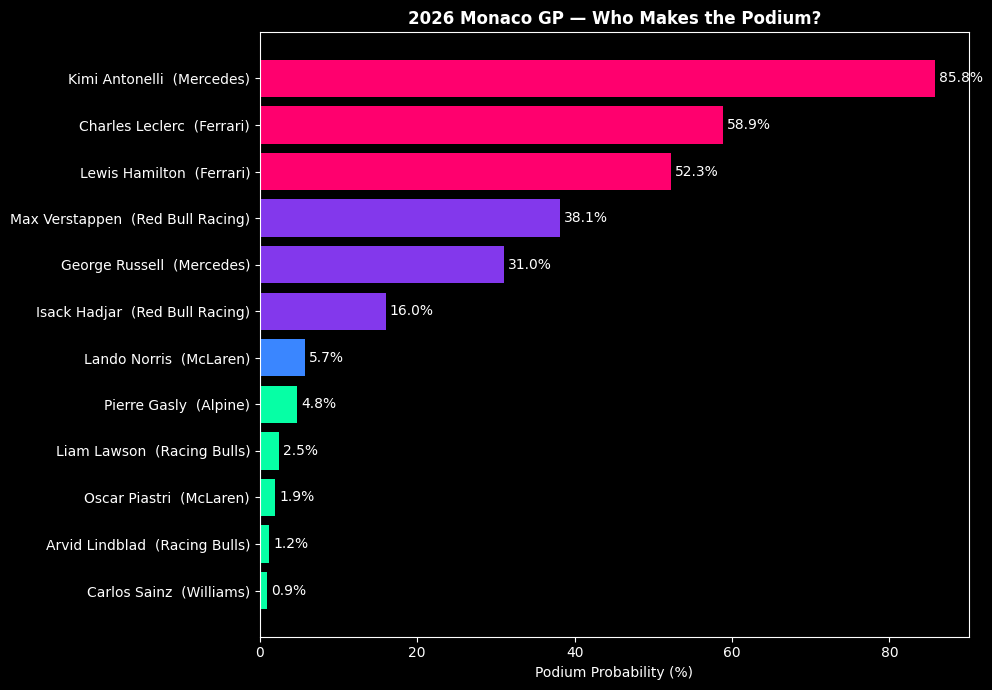

## 4. Race Results & Model Accuracy

The race has run — time to grade the model. Predicted order against the official classification: position-by-position error, podium / top-5 / top-10 accuracy, and the standout calls and misses. These numbers feed the season scoreboard.

```
=====================================================================================
  🏁 OFFICIAL RESULTS vs MODEL — 2026 Monaco GP
=====================================================================================

  Fin  Driver                  Team                Pred   Err  Status
  ------------------------------------------------------------------------------
  P 1  Kimi Antonelli          Mercedes            P 1     0  Finished 🎯
  P 2  Lewis Hamilton          Ferrari             P 3     1  Finished
  P 3  Isack Hadjar            Red Bull Racing     P 6     3  Finished
  P 4  Oscar Piastri           McLaren             P 8     4  Finished
  P 5  Liam Lawson             Racing Bulls        P10     5  Finished
  P 6  Arvid Lindblad          Racing Bulls        P11     5  Finished
  P 7  Pierre Gasly            Alpine              P 9     2  Finished
  P 8  Alexander Albon         Williams            P13     5  Finished
  P 9  Esteban Ocon            Haas F1 Team        P18     9  Finished
  P10  Fernando Alonso         Aston Martin        P20    10  Finished
  P11  Gabriel Bortoleto       Audi                P16     5  Finished
  P12  George Russell          Mercedes            P 5     7  Finished
  P13  Nico Hulkenberg         Audi                P15     2  Finished
  P14  Franco Colapinto        Alpine              P14     0  Finished 🎯
  P15  Sergio Perez            Cadillac            P19     4  Finished
  P16  Carlos Sainz            Williams            P12   DNF  Retired
  P17  Charles Leclerc         Ferrari             P 2   DNF  Retired
  P18  Lance Stroll            Aston Martin        P21   DNF  Retired
  P19  Lando Norris            McLaren             P 7   DNF  Retired
  P20  Oliver Bearman          Haas F1 Team        P17   DNF  Retired
  P21  Valtteri Bottas         Cadillac            P22   DNF  Retired
  P22  Max Verstappen          Red Bull Racing     P 4   DNF  Retired

  📊 SCORECARD
  ------------------------------------------------------------
  Predicted winner:  Kimi Antonelli
  Actual winner:     Kimi Antonelli  ✅
  Podium accuracy:   2/3
  Top 5 accuracy:    2/5   (grid baseline: 3/5)
  Top 10 accuracy:   6/10  (grid baseline: 6/10)
  MAE (classified):  4.13 positions  (validation expected 2.27)

  🏁 vs GRID BASELINE (does the model beat 'finish = qualifying order'?)
  Grid-copy MAE:     3.87 positions
  Model edge:        -0.27  ->  grid beats model

  🎯 Best calls:   Kimi Antonelli (P1→P1), Franco Colapinto (P14→P14), Lewis Hamilton (P3→P2)
  💥 Worst misses: Fernando Alonso (pred P20, fin P10), Esteban Ocon (pred P18, fin P9), George Russell (pred P5, fin P12)
  🔧 DNFs: Carlos Sainz, Charles Leclerc, Lance Stroll, Lando Norris, Oliver Bearman, Valtteri Bottas, Max Verstappen
```

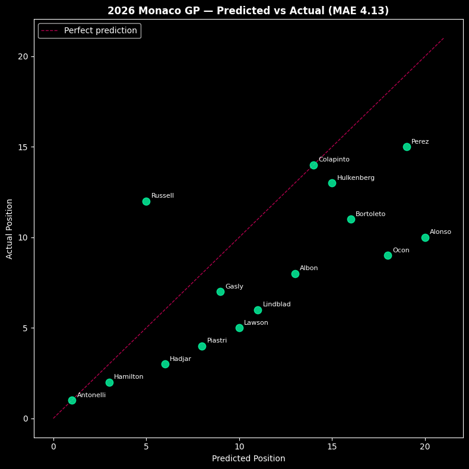